# THE WHALING VOYAGES 1750s-1790's

#### Final Project for Data: A User Manual (CU Denver, Fall 2021)

**Introduction**

The dataset I have chosen to analyze for my final project for Hist 5261 is the data for all whaling voyages during the 1750-1790’s. This data includes all the information about the voyages American colonial ships made for American whaling expeditions in the 1750s. These expeditions were done to hunt whales for whale oil, which was used for a variety of different goods. This came from the American Whaling Voyages dataset. This data set, along with several other datasets, were compiled by Whaling History, a database that showcases data of whaling history, including British and American whaling voyages and crews as well as whale species. The data is in a csv file, making it easy to study on Python. I look forward to studying and analyzing this data set.

I plan on analyzing several components. First, I plan on anlayzing the amount of sperm that American whalers obtained between 1750 and 1799. Second I plan to do the same with whale oil. I believe that both increased after the American Revolution. Then I plan to see which port was the center of American Whaling or was the most frequent port mentioned in the ledgers and logbooks. The last one should result in one or two, but I may find several ports instead of one port.

**The Data**

The Data of the American Wnhaling Voyages from the 1750s to 1790s was collected by different port ledgers, ledgers of whaling companies companies and captain’s logs. The information from these ledgers and logs was compiled altogther into one dataset by the American Whaling Voygaes dataset. This would mean that the historians, before looking at this data, should know that the data may be limited because either whaling captain’s logbooks went missing or that port ledgers may not have all of the records fully intact. The records were recorded just like other port entries and where recording the voyage, the ship, captain’s name, etc. This survey analyzes the whaling voyages and the basic information about each of the whaling voyages during a section of the history of American whaling, the voyages done between 1750 and 1790.

```python
import pandas as pd
import os
```

```python
#os.getcwd()
```

```python
whaling_df = pd.read_csv('whaling_data.csv', delimiter=",")
whaling_df.head()
```

|  | VoyageID | Voyage | Port | Sailing From | Ground | Year | Year In | Sperm | Oil | Source | MasterID | Master | Fate | VesselID | Vessel | Rig | Tonnage |
| --- | --- | --- | --- | --- | --- | --- | --- | --- | --- | --- | --- | --- | --- | --- | --- | --- | --- |
| 0 | AV14355 | Unknown : 1750 | Unknown | NaN | Davis St | 1750 | 1750.0 | NaN | NaN | 1, 4 | AM0177 | Atkins | NaN | AS0000 | Unknown | NaN | NaN |
| 1 | AV04751 | Experiment : 1751 | Williamsburg, VA | NaN | Atlantic | 1751 | 1751.0 | NaN | 20.0 | 4, 157 | AM0000 | Unknown | NaN | AS1334 | Experiment | Sloop | NaN |
| 2 | AV05973 | Grampus : 1751 | Nantucket, MA | NaN | Offshore | 1751 | 1751.0 | 45.0 | NaN | 48, 5, 125, 520 | AM0721 | Bunker, Benjamin | NaN | AS1501 | Grampus | Schr / Sloop | NaN |
| 3 | AV05974 | Grampus : 1751 | Nantucket, MA | NaN | Offshore | 1751 | 1751.0 | 20.0 | NaN | 48, 5, 125, 520 | AM0721 | Bunker, Benjamin | NaN | AS1501 | Grampus | Schr / Sloop | NaN |
| 4 | AV05975 | Grampus : 1751 | Nantucket, MA | NaN | Offshore | 1751 | 1751.0 | 70.0 | NaN | 48, 5, 125, 520 | AM0721 | Bunker, Benjamin | NaN | AS1501 | Grampus | Schr / Sloop | NaN |

```python
whaling_df['Port'] = whaling_df['Port'].str.replace('Nantucket, MA ?','Nantucket, MA')
whaling_df['Port'] = whaling_df['Port'].str.replace('Nantucket, MA?','Nantucket, MA')
```

```python
whaling_df['Port'] = whaling_df['Port'].str.replace('New Bedford, MA ?','New Bedford, MA')
whaling_df['Port'] = whaling_df['Port'].str.replace('New Bedford, MA?','New Bedford, MA')
```

```python
whaling_df.head()
```

|  | VoyageID | Voyage | Port | Sailing From | Ground | Year | Year In | Sperm | Oil | Source | MasterID | Master | Fate | VesselID | Vessel | Rig | Tonnage |
| --- | --- | --- | --- | --- | --- | --- | --- | --- | --- | --- | --- | --- | --- | --- | --- | --- | --- |
| 0 | AV14355 | Unknown : 1750 | Unknown | NaN | Davis St | 1750 | 1750.0 | NaN | NaN | 1, 4 | AM0177 | Atkins | NaN | AS0000 | Unknown | NaN | NaN |
| 1 | AV04751 | Experiment : 1751 | Williamsburg, VA | NaN | Atlantic | 1751 | 1751.0 | NaN | 20.0 | 4, 157 | AM0000 | Unknown | NaN | AS1334 | Experiment | Sloop | NaN |
| 2 | AV05973 | Grampus : 1751 | Nantucket, MA | NaN | Offshore | 1751 | 1751.0 | 45.0 | NaN | 48, 5, 125, 520 | AM0721 | Bunker, Benjamin | NaN | AS1501 | Grampus | Schr / Sloop | NaN |
| 3 | AV05974 | Grampus : 1751 | Nantucket, MA | NaN | Offshore | 1751 | 1751.0 | 20.0 | NaN | 48, 5, 125, 520 | AM0721 | Bunker, Benjamin | NaN | AS1501 | Grampus | Schr / Sloop | NaN |
| 4 | AV05975 | Grampus : 1751 | Nantucket, MA | NaN | Offshore | 1751 | 1751.0 | 70.0 | NaN | 48, 5, 125, 520 | AM0721 | Bunker, Benjamin | NaN | AS1501 | Grampus | Schr / Sloop | NaN |

[figure not shown]

**Analysis**

The data showcases a variety of things including the ships, captains, ports, voyages made, the sperm gathered from Sperm whales, and the oil obtained by whaling overall. The data though can tell us bits about it but without the context one would think that Sperm and oil with two different things.

```python
whaling_df.describe(include='all')
```

|  | VoyageID | Voyage | Port | Sailing From | Ground | Year | Year In | Sperm | Oil | Source | MasterID | Master | Fate | VesselID | Vessel | Rig | Tonnage |
| --- | --- | --- | --- | --- | --- | --- | --- | --- | --- | --- | --- | --- | --- | --- | --- | --- | --- |
| count | 1869 | 1869 | 1805 | 6 | 753 | 1869.000000 | 716.000000 | 273.000000 | 369.000000 | 1868 | 1869 | 1869 | 30 | 1869 | 1869 | 988 | 314 |
| unique | 1845 | 1032 | 91 | 4 | 142 | NaN | NaN | NaN | NaN | 539 | 1069 | 976 | 4 | 551 | 289 | 29 | 87 |
| top | AV11333 | Unknown : 1772- | Nantucket, MA | Nantucket | Grand Banks | NaN | NaN | NaN | NaN | 758 | AM0000 | Unknown | R | AS0000 | Unknown | Ship | 150 |
| freq | 2 | 71 | 732 | 3 | 130 | NaN | NaN | NaN | NaN | 199 | 109 | 106 | 11 | 821 | 822 | 260 | 15 |
| mean | NaN | NaN | NaN | NaN | NaN | 1777.695024 | 1783.224860 | 288.553114 | 456.590786 | NaN | NaN | NaN | NaN | NaN | NaN | NaN | NaN |
| std | NaN | NaN | NaN | NaN | NaN | 13.113615 | 13.586027 | 407.190461 | 491.432332 | NaN | NaN | NaN | NaN | NaN | NaN | NaN | NaN |
| min | NaN | NaN | NaN | NaN | NaN | 1750.000000 | 1750.000000 | 0.000000 | 0.000000 | NaN | NaN | NaN | NaN | NaN | NaN | NaN | NaN |
| 25% | NaN | NaN | NaN | NaN | NaN | 1769.000000 | 1773.000000 | 20.000000 | 60.000000 | NaN | NaN | NaN | NaN | NaN | NaN | NaN | NaN |
| 50% | NaN | NaN | NaN | NaN | NaN | 1775.000000 | 1788.000000 | 100.000000 | 200.000000 | NaN | NaN | NaN | NaN | NaN | NaN | NaN | NaN |
| 75% | NaN | NaN | NaN | NaN | NaN | 1790.000000 | 1794.000000 | 300.000000 | 800.000000 | NaN | NaN | NaN | NaN | NaN | NaN | NaN | NaN |
| max | NaN | NaN | NaN | NaN | NaN | 1799.000000 | 1804.000000 | 2500.000000 | 2400.000000 | NaN | NaN | NaN | NaN | NaN | NaN | NaN | NaN |

Historians have mainly focused on the 1810s to 1850s, which is considered to be the Golden Age of Whaling. However fortunately there are whaling sources outside of the American Whaling Database. Tim D. Smith, Randall R. Reeves, Elizabeth A. Josephson, and Judith N. Lund describe the patterns of whaling and how sperm whales were more commonly found later on in the South Atlantic and Pacific Oceans. PBS's history of whaling series did a whole timeline of whaling. It notes how only after the introduction of the Tryworks, which converted oil from whale blabber, the whaling industry was able to sail longer voyages and hunt more whales. It further provides additional context for the whaling.

[figure not shown]

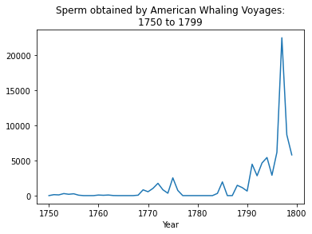

```python
whaling_sperm_df = whaling_df[['Voyage', 'Year', 'Sperm']]
total_sperm_by_year = whaling_sperm_df.groupby('Year')['Sperm'].sum()
total_sperm_by_year.plot(kind='line', title="Sperm obtained by American Whaling Voyages:\n1750 to 1799")
```

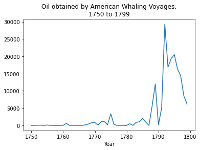

```python
whaling_oil_df = whaling_df[['Voyage', 'Year', 'Year In', 'Oil']]
total_oil_by_year = whaling_oil_df.groupby('Year')['Oil'].sum()
total_oil_by_year.plot(kind='line', title="Oil obtained by American Whaling Voyages:\n1750 to 1799")
```

The whaling voyages' gains of oil are remarkably similar to sperm in that the peak of whaling voyages gaining lots of oil occurred later on after the signing of the United States Constitution. The American his could be that whalers made more of a profit since the British navy was focused on ferrying British troops to the colonies instead of patrolling possible breeding areas of whales. American whaling had its first boom in 1788 and then again in the early 1790s. This was during the days of the French Revolution, so the whalers were left undisturbed perhaps or that the whale's population had boomed. Then whale oil declined in number during the late 1790s. This times well with the rise of Napoleon. Therefore, either the whales declined in number and the whalers had to search for more whales or that the British were capturing American ships to obtain the oil or prevent the whalers from hunting oil that could be obtained by British whalers.

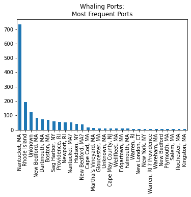

```python
whaling_port_df = whaling_df[['Voyage', 'Year', 'Port']]
whaling_port_df.value_counts()[:20]
whaling_df['Port'].value_counts()[:30].plot(kind='bar', title='Whaling Ports:\nMost Frequent Ports')
```

The most common port used by the whaling voyages is the port of Nantucket, Massachusetts. This port is the most common port noted, but one of numerous ports from Massachusetts. If this port is very well featured in a variety of formats, then Nantucket was the main port and center of American Whaling. Rhode Island is next. However, the port is not specified in Rhode Island. Thus a historian has to presume that either the port was the only one so the colony/state was used or that the port was not rememberable since Rhode Island is used for the port.

**Conclusion**

**Bibliography**

The dataset for all whaling voyages during the 1750-1790’s has all the information about the voyages American colonial ships made for American whaling expeditions in the 1750s. These expeditions were done to hunt whales for whale oil, which was used for a variety of different goods. This came from the American Whaling Voyages dataset. This data set, along with several other datasets, were compiled by Whaling History, a database that showcases data of whaling history, including British and American whaling voyages and crews as well as whale species. The data is in a csv file, making it easy to study on Python. I look forward to studying and analyzing this data set.

The Whaling Voyages dataset was a collection of the variety of American whaling voyages that have been recorded from the 1700’s to the end of the 19th century. It was first record through whaling companies and captain’s logs. This would mean that the historians, before looking at this data, should know that the data may be limited because either whaling captain’s logbooks went missing or that port ledgers may not have all of the records fully intact. The records were recorded just like other port entries and where recording the voyage, the ship, captain’s name, etc. This was the end result of the data I analyzed. This survey analyzes the whaling voyages and the basic information about each of the whaling voyages during a section of the history of American whaling, the voyages done between 1750 and 1790.

These records were collected by The Whaling History, a database showcasing all. This database is a collaboration between Mystic Seaport Museum and New Bedford Whaling Museum, both in New England. This leaves how they received it to the interpretation of the history, which may lead to American whaling to be determined by New England museums that may hide some data that is not favorable. The data was processed, digitized and made available to the public online by The Whaling History starting in 2018, even updating findings in 2021. They used a spreadsheet similar to a museum data-spread sheet. The data of the collection itself is is a csv format, which is created by selecting specific sets of data from the database. Otherwise other 200,000 entries would be shown but you cannot download it. The selection of the dataset opens up in the data set website, but can’t let you download it. I was able to select the data with the time period I chose and download the data completely.

There are a few problems with the data that would limit its usefulness to historians. Upon reading the data, it appears that the data shows only the basic information about the voyage, not necessarily including the crew, weather conditions, etc. As a result, the data shown here is only relating to voyages by whaling ships. The data does not record the crew members. That though is included in a separate data set. The data further notes specific ships and ports, not necessarily if they had to stop at all. This is a problem because the whaling voyages were treated like business entries. There are also holes in captain or destination columns. A problem with the website and database is that the cvs format only is accessible once you select a specific time period in the database. Otherwise, you won’t be able to download the data. This will mean that the data on the cvs format could not be accessed unless a historian would select a time period. If it can’t upload, than there is no other option to view it. This would help historians look at the details of the American whaling voyages.

The dataset I have chosen to analyze for my final project for Hist 5261 is the data for all whaling voyages during the 1750-1790’s. This data includes all the information about the voyages American whaling expeditions made during the latter half of the 18th century. These expeditions were done to hunt whales for whale oil, which was used for a variety of different goods. This came from the American Whaling Voyages dataset. This data set, along with several other datasets, were compiled by Whaling History, a database that showcases data of whaling history, including British and American whaling voyages and crews as well as whale species. The data is in a csv file, making it easy to use on pandas on Python. I can’t wait to study this interesting and unique dataset.

**Works Cited**

Davis, L. E., R. E. Gallman, and T. D. Hutchins. “Technology, Productivity, and Profits: British–American Whaling Competition in the North Atlantic, 1816-1842.” Oxford Economic Papers 39, no. 4 (1987): 738–59. http://www.jstor.org/stable/2663104.

Davis, Lance E., Robert E. Gallman, and Teresa D. Hutchins. "The Decline of U.S. Whaling: Was the Stock of Whales Running Out?" Business History Review 62, no. 4 (1988): 569-95. doi:10.2307/3115618.

Smith TD, Reeves RR, Josephson EA, Lund JN (2012) Spatial and Seasonal Distribution of American Whaling and Whales in the Age of Sail. PLOS ONE 7(4): e34905. https://doi.org/10.1371/journal.pone.0034905

PBS."THE AMERICAN EXPERINCE:Into the Deep: America, Whaling & the World". https://www.pbs.org/wgbh/americanexperience/features/whaling-history-whaling-america/